# Visualising wealth inequality in the US

2024-06-05

# Wealth inequality

Our [recent paper](https://github.com/jhsuss/wealth-inequality/) provides the first estimates of wealth and wealth inequality in the US. We have made the data [publicly available](https://www.openicpsr.org/openicpsr/project/192306/version/V4/view) in the hope of spurring research on the causes and consequences of local wealth inequality. Let’s examine some of this data (at the Commuting Zone level, for the years 1960-2022) here.

## Get started

First load necessary libraries (or install if don’t yet have) and the data.

Let’s peruse the data. There are a lot of variables aside from the inequality estimates to explore!

```r
glimpse(ineq)
```

[output not shown]

[output cut: 35 more lines]

## Descriptives

How does within-area wealth inequality in 1960 relate to wealth inequality in 2020. Let’s look at a scatter plot of the top 1% share in both years.

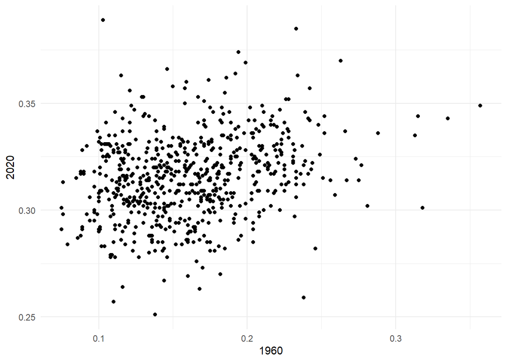

```r
# reshape data and plot
ggplot(ineq %>%
         filter(year %in% c(1960,2020)) %>%
         select(year, czone, wealth_top1) %>%
         pivot_wider(names_from = year, values_from = wealth_top1),
       aes(x = `1960`, y = `2020`)
       ) +
  geom_point()
```

## Maps

Let’s look at some maps now. First, we need to read in some shapefiles.

```r
# shapefiles can be conveniently downloaded using the ussf package, see how to install in github link
#https://github.com/dcl-docs/ussf
#remotes::install_github("dcl-docs/ussf")
czs <- ussf::boundaries(geography = "cz") %>%
  rename(cz = cz_1990) %>%
  mutate(cz = as.numeric(cz)) %>%
  st_transform("EPSG:5070")

# merge shapefiles
ineq <- ineq %>%
  left_join(
    czs,
    by = c("czone" = "cz")
  )
```

Now let’s have a look at the spatial variation in inequality

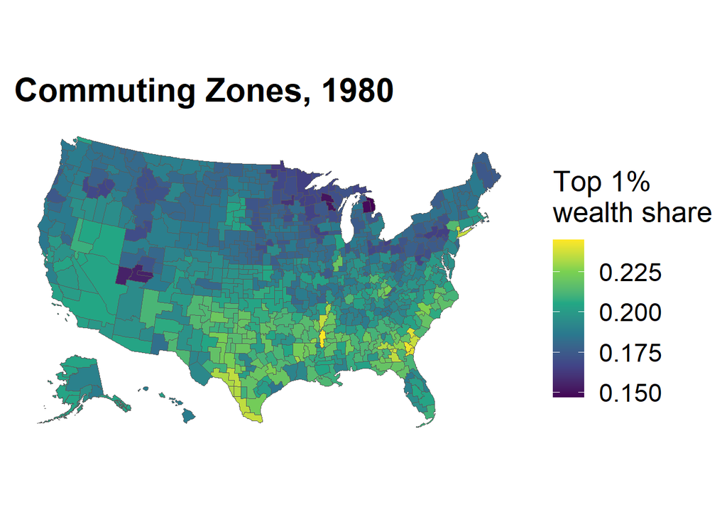

```r
ggplot(
  data = ineq %>%
    filter(
      year == 1980
    )
  ) +
  geom_sf(
    mapping = aes(
      geometry = geometry,
      fill = wealth_top1
    )
  ) +
  labs(
    fill = "Top 1%\nwealth share",
    title = "Commuting Zones, 1980"
  ) +
  scale_fill_viridis_c(option = "D") +
  theme_map(font_size = 20)
```

Let’s look at a how average wealth has evolved over time.

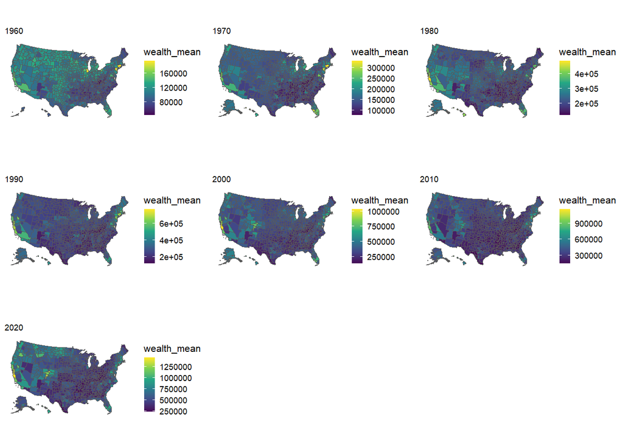

```r
g <- purrr::map(ineq %>% filter(str_detect(year, "0$")) %>% .$year %>% unique,
                function(x) {
                  ggplot(
                    data = ineq %>%
                      filter(
                        year == x
                      )
                  ) +
                    geom_sf(
                      mapping = aes(
                        geometry = geometry,
                        fill = wealth_mean
                      )
                    ) +
                    labs(subtitle = x) +
                    scale_fill_viridis_c(option = "D") +
                    theme_map(font_size = 8)


                })

plot_grid(plotlist = g)
```

## Associations

Let’s look at how within-area wealth inequality is associated with key demographics, education and race. To do this, I’ll look at a cross-section of the data, taking the year 2020.

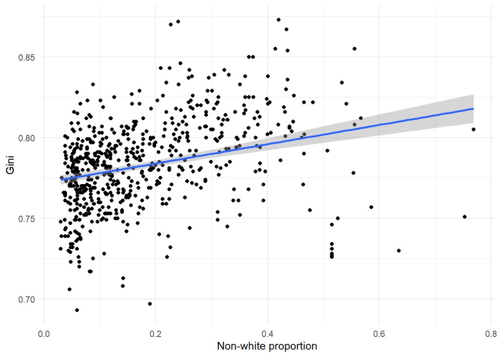

```r
ggplot(
  ineq %>%
    filter(year == 2020),
  aes(x = 1-white, y = wealth_gini)
  ) +
  geom_point() +
  geom_smooth(method = "lm") +
  labs(
    x = "Non-white proportion", y = "Gini"
  )
```

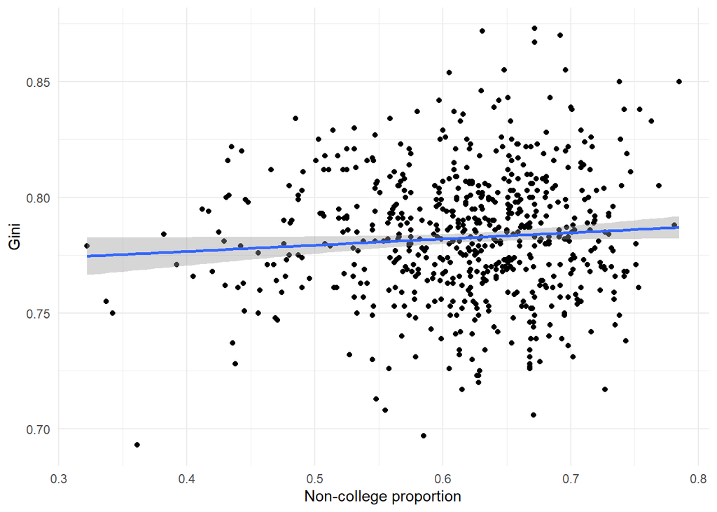

```r
ggplot(
  ineq %>%
    filter(year == 2020),
  aes(x = 1-college, y = wealth_gini)
  ) +
  geom_point() +
  geom_smooth(method = "lm") +
  labs(
    x = "Non-college proportion", y = "Gini"
  )
```

## What other patterns can you find?

Some questions: how has wealth inequality evolved over time within and between places? What explains the variation in wealth inequality over time and space?

Feel free to add in other data! For example, you can get social mobility data at the Commuting Zone level (from Raj Chetty et al using Facebook data): https://opportunityatlas.org/.

```r
# your code here
```